# Storms and other severe weather events impact on both public health and economic problems for communities and municipalities in USA.

## Synopsis

In this report we aim to describe what event type of weather impact population health and economic consequences in the Unitied States between the year 1950 and 2011. Our overall hypothesis is that different event types of weather will make big impact on populatio health and economic dmage. To investigate this hypothesis, we obtained storm dataset from US National Oceanic and Atmosphereic Administrations in US. From these data we analyzed, we found that tornado have the greatest economic consequences in USA, and multiple type of weather have affected population health since the mid-1980s.

## Data processing

### Loading the Raw Data

```r
### dowonloading file
fileUrl <- "https://d396qusza40orc.cloudfront.net/repdata%2Fdata%2FStormData.csv.bz2"
if(!file.exists("./data")){dir.create("./data")}
bzipFile <- "./data/repdata-data-StormData.csv.bz2"    #name bz file
if (!file.exists(bzipFile)) {
        download.file(fileUrl, destfile = bzipFile, method = "curl")
}

### read raw source file
rawSD <- read.csv(bzfile(bzipFile), na.strings = "", stringsAsFactors = FALSE, comment.char = "#")
```

### check the data

```r
str(rawSD)
```

```
## 'data.frame':    902297 obs. of  37 variables:
##  $ STATE__   : num  1 1 1 1 1 1 1 1 1 1 ...
##  $ BGN_DATE  : chr  "4/18/1950 0:00:00" "4/18/1950 0:00:00" "2/20/1951 0:00:00" "6/8/1951 0:00:00" ...
##  $ BGN_TIME  : chr  "0130" "0145" "1600" "0900" ...
##  $ TIME_ZONE : chr  "CST" "CST" "CST" "CST" ...
##  $ COUNTY    : num  97 3 57 89 43 77 9 123 125 57 ...
##  $ COUNTYNAME: chr  "MOBILE" "BALDWIN" "FAYETTE" "MADISON" ...
##  $ STATE     : chr  "AL" "AL" "AL" "AL" ...
##  $ EVTYPE    : chr  "TORNADO" "TORNADO" "TORNADO" "TORNADO" ...
##  $ BGN_RANGE : num  0 0 0 0 0 0 0 0 0 0 ...
##  $ BGN_AZI   : chr  NA NA NA NA ...
##  $ BGN_LOCATI: chr  NA NA NA NA ...
##  $ END_DATE  : chr  NA NA NA NA ...
##  $ END_TIME  : chr  NA NA NA NA ...
##  $ COUNTY_END: num  0 0 0 0 0 0 0 0 0 0 ...
```

[output cut: 23 more lines]

### Varialbes related with questions

We have to choose some variables for solving two questions - Across the United States, which types of events (as indicated in the EVTYPE variable) are most harmful with respect to population health?

- Across the United States, which types of events have the greatest economic consequences?

Base variables : BGN_DATE, STATE, EVTYPE(event type) Variables related with population health : FATALITIES, INJURIES Variables related with economic : PROPDMG(property dmage), PROPDMGEXP(property dmage exponents), CROPDMG(crop), CROPDMBEXP

```r
newCol <- c("STATE", "BGN_DATE", "EVTYPE", "PROPDMGEXP", "CROPDMGEXP", "FATALITIES", "INJURIES", "PROPDMG", "CROPDMG")
newSD <- rawSD[, newCol]
str(newSD)
```

```
## 'data.frame':    902297 obs. of  9 variables:
##  $ STATE     : chr  "AL" "AL" "AL" "AL" ...
##  $ BGN_DATE  : chr  "4/18/1950 0:00:00" "4/18/1950 0:00:00" "2/20/1951 0:00:00" "6/8/1951 0:00:00" ...
##  $ EVTYPE    : chr  "TORNADO" "TORNADO" "TORNADO" "TORNADO" ...
##  $ PROPDMGEXP: chr  "K" "K" "K" "K" ...
##  $ CROPDMGEXP: chr  NA NA NA NA ...
##  $ FATALITIES: num  0 0 0 0 0 0 0 0 1 0 ...
##  $ INJURIES  : num  15 0 2 2 2 6 1 0 14 0 ...
##  $ PROPDMG   : num  25 2.5 25 2.5 2.5 2.5 2.5 2.5 25 25 ...
##  $ CROPDMG   : num  0 0 0 0 0 0 0 0 0 0 ...
```

### Convert the date and make new column DATE without time

```r
Sys.setlocale("LC_TIME","C")
```

```
## [1] "C"
```

```r
newSD$BGN_DATE <- as.Date(newSD$BGN_DATE, format = "%m/%d/%Y %H:%M:%S")
newSD$DATE <- as.Date(newSD$BGN_DATE, format = "%m/%d/%Y")
```

### Check exponet value

```r
unique(newSD$PROPDMGEXP)
```

```
##  [1] "K" "M" NA  "B" "m" "+" "0" "5" "6" "?" "4" "2" "3" "h" "7" "H" "-"
## [18] "1" "8"
```

```r
unique(newSD$CROPDMGEXP)
```

```
## [1] NA  "M" "K" "m" "B" "?" "0" "k" "2"
```

Calulating the exponent value - H or H for hundred - K or k for thousand - M or m for million - B or b for billion

```r
exp <- c(0:9, "h", "H", "k", "K", "m", "M", "b", "B", "-", "+", "?", NA)
real = c(10^(0:9), 10^2, 10^2, 10^3, 10^3, 10^6, 10^6, 10^9, 10^9, 1, 1, 1, 1)

newSD$PROPDMGreal <- newSD$PROPDMG * real[match(newSD$PROPDMGEXP, exp)]
newSD$CROPDMGreal <- newSD$CROPDMG * real[match(newSD$CROPDMGEXP, exp)]
str(newSD)
```

```
## 'data.frame':    902297 obs. of  12 variables:
##  $ STATE      : chr  "AL" "AL" "AL" "AL" ...
##  $ BGN_DATE   : Date, format: "1950-04-18" "1950-04-18" ...
##  $ EVTYPE     : chr  "TORNADO" "TORNADO" "TORNADO" "TORNADO" ...
##  $ PROPDMGEXP : chr  "K" "K" "K" "K" ...
##  $ CROPDMGEXP : chr  NA NA NA NA ...
##  $ FATALITIES : num  0 0 0 0 0 0 0 0 1 0 ...
##  $ INJURIES   : num  15 0 2 2 2 6 1 0 14 0 ...
##  $ PROPDMG    : num  25 2.5 25 2.5 2.5 2.5 2.5 2.5 25 25 ...
##  $ CROPDMG    : num  0 0 0 0 0 0 0 0 0 0 ...
##  $ DATE       : Date, format: "1950-04-18" "1950-04-18" ...
##  $ PROPDMGreal: num  25000 2500 25000 2500 2500 2500 2500 2500 25000 25000 ...
##  $ CROPDMGreal: num  0 0 0 0 0 0 0 0 0 0 ...
```

### Check the value of event type

```r
unique(newSD$EVTYPE)[1:100]
```

```
##   [1] "TORNADO"                        "TSTM WIND"
##   [3] "HAIL"                           "FREEZING RAIN"
##   [5] "SNOW"                           "ICE STORM/FLASH FLOOD"
##   [7] "SNOW/ICE"                       "WINTER STORM"
##   [9] "HURRICANE OPAL/HIGH WINDS"      "THUNDERSTORM WINDS"
##  [11] "RECORD COLD"                    "HURRICANE ERIN"
##  [13] "HURRICANE OPAL"                 "HEAVY RAIN"
##  [15] "LIGHTNING"                      "THUNDERSTORM WIND"
##  [17] "DENSE FOG"                      "RIP CURRENT"
##  [19] "THUNDERSTORM WINS"              "FLASH FLOOD"
##  [21] "FLASH FLOODING"                 "HIGH WINDS"
##  [23] "FUNNEL CLOUD"                   "TORNADO F0"
##  [25] "THUNDERSTORM WINDS LIGHTNING"   "THUNDERSTORM WINDS/HAIL"
##  [27] "HEAT"                           "WIND"
##  [29] "LIGHTING"                       "HEAVY RAINS"
```

[output cut: 35 more lines]

Event type (EVTYPE) has 985 unique levles. But it is too dirty. There are many duplicated expresion. We have to clean up. First of all, classify event types - TORNADO, WIND, HAIL, RAIN, SNOW, STORM, FLOOD, HURRICANE, DUST, COLD, HOT, DRY, WET, SURF, FIRE

```r
newSD[grep("[Tt][Oo][Rr]", newSD$EVTYPE, ignore.case = TRUE), c("EVTYPE")] <- "TORNADO"
newSD[grep("[Hh][Aa][Ii]", newSD$EVTYPE, ignore.case = TRUE), c("EVTYPE")] <- "HAIL"
newSD[grep("[Tt][Ss][Uu]", newSD$EVTYPE, ignore.case = TRUE), c("EVTYPE")] <- "HAIL"
newSD[grep("[Ww][Ii][Nn]", newSD$EVTYPE, ignore.case = TRUE), c("EVTYPE")] <- "WIND"
newSD[grep("[Rr][Aa][Ii]", newSD$EVTYPE, ignore.case = TRUE), c("EVTYPE")] <- "RAIN"
newSD[grep("[Ss][Hh][Oo]", newSD$EVTYPE, ignore.case = TRUE), c("EVTYPE")] <- "RAIN"
newSD[grep("[Ss][Nn][Oo]", newSD$EVTYPE, ignore.case = TRUE), c("EVTYPE")] <- "SNOW"
newSD[grep("[Aa][Vv][Aa][Ll]", newSD$EVTYPE, ignore.case = TRUE), c("EVTYPE")] <- "SNOW"
newSD[grep("[Bb][Ll][Ii][Zz]", newSD$EVTYPE, ignore.case = TRUE), c("EVTYPE")] <- "SNOW"
newSD[grep("[Ff][Ll][Oo]", newSD$EVTYPE, ignore.case = TRUE), c("EVTYPE")] <- "FLOOD"
newSD[grep("[Ss][Tt][Oo]", newSD$EVTYPE, ignore.case = TRUE), c("EVTYPE")] <- "STORM"
```

```r
newSD[grep("[Tt][Yy][Pp]", newSD$EVTYPE, ignore.case = TRUE), c("EVTYPE")] <- "STORM"
newSD[grep("[Hh][Uu][Rr]", newSD$EVTYPE, ignore.case = TRUE), c("EVTYPE")] <- "HURRICANE"
newSD[grep("[Ff][Oo][Gg]", newSD$EVTYPE, ignore.case = TRUE), c("EVTYPE")] <- "FOG"
newSD[grep("[Cc][Ll][Oo]", newSD$EVTYPE, ignore.case = TRUE), c("EVTYPE")] <- "CLOUD"
newSD[grep("[Dd][Uu][Ss]", newSD$EVTYPE, ignore.case = TRUE), c("EVTYPE")] <- "DUST"
newSD[grep("[Cc][Oo][Ll]", newSD$EVTYPE, ignore.case = TRUE), c("EVTYPE")] <- "COLD"
newSD[grep("[Fr][Rr][Ee]", newSD$EVTYPE, ignore.case = TRUE), c("EVTYPE")] <- "COLD"
newSD[grep("[Ii][Cc][Ee]", newSD$EVTYPE, ignore.case = TRUE), c("EVTYPE")] <- "COLD"
newSD[grep("[Hh][Oo][Tt]", newSD$EVTYPE, ignore.case = TRUE), c("EVTYPE")] <- "HOT"
newSD[grep("[Hh][Ee][Aa]", newSD$EVTYPE, ignore.case = TRUE), c("EVTYPE")] <- "HOT"
newSD[grep("[Dd][Rr][Yy]", newSD$EVTYPE, ignore.case = TRUE), c("EVTYPE")] <- "DRY"
newSD[grep("[Ww][Ee][Tt]", newSD$EVTYPE, ignore.case = TRUE), c("EVTYPE")] <- "WET"
newSD[grep("[Ss][Uu][Rr]", newSD$EVTYPE, ignore.case = TRUE), c("EVTYPE")] <- "SURF"
newSD[grep("[Ff][Ii][Rr]", newSD$EVTYPE, ignore.case = TRUE), c("EVTYPE")] <- "FIRE"
```

Subsetting event types from origin data (newSD)

```r
eventType <- c("TORNADO","HAIL", "WIND", "RAIN", "SNOW", "FLOOD", "STORM", "HURRICANE", "FOG", "CLOUD", "DUST", "COLD", "HOT", "DRY", "WET", "SURF", "FIRE")

new2SD <- subset(newSD, EVTYPE == eventType)
```

## Results

### Correlation between evet types and population health

Calculate total FATALITIES and INJURIES per event types and show it in time period

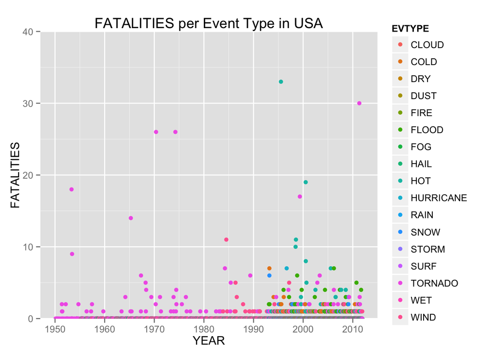

```r
new2SDFatal <- aggregate(FATALITIES ~ EVTYPE + DATE, new2SD, sum)
new2SDInju <- aggregate(INJURIES ~ EVTYPE + DATE, new2SD, sum)

### Population health chart
library(ggplot2)
# FATALITIES : extension (without outlier)
ggplot(new2SDFatal, aes(DATE, FATALITIES)) + geom_point(aes(color=EVTYPE), size =2) + coord_cartesian(ylim=c(0,40)) + labs(x= "YEAR", y="FATALITIES", title="FATALITIES per Event Type in USA")
```

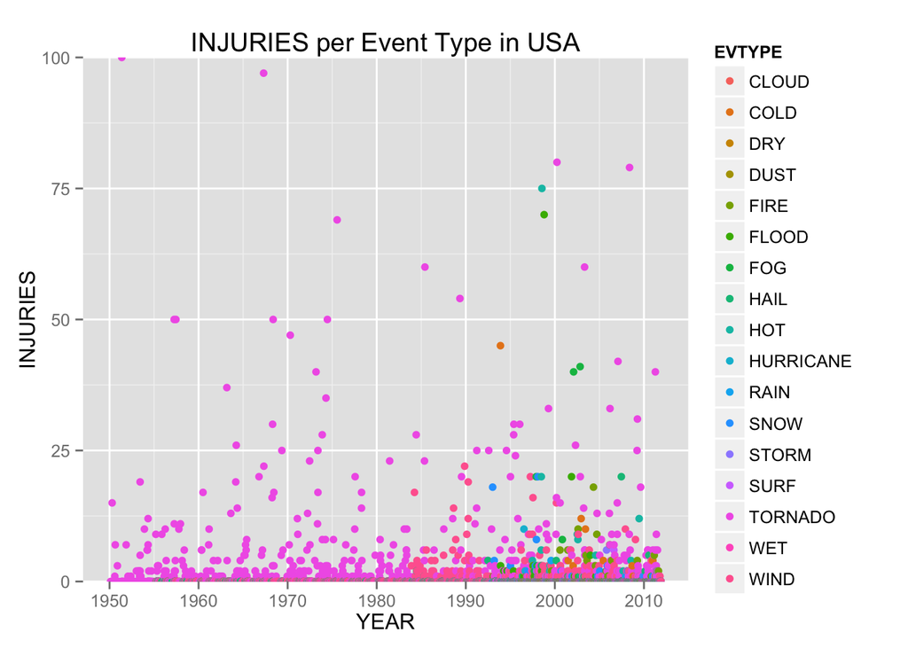

```r
# INJURIES : extension (without outlier)
ggplot(new2SDInju, aes(DATE, INJURIES)) + geom_point(aes(color=EVTYPE), size =2) + coord_cartesian(ylim=c(0,100)) + labs(x= "YEAR", y="INJURIES", title="INJURIES per Event Type in USA")
```

The TORNADO is the most hamful to population health.

### Correlation between event types and economic consequences

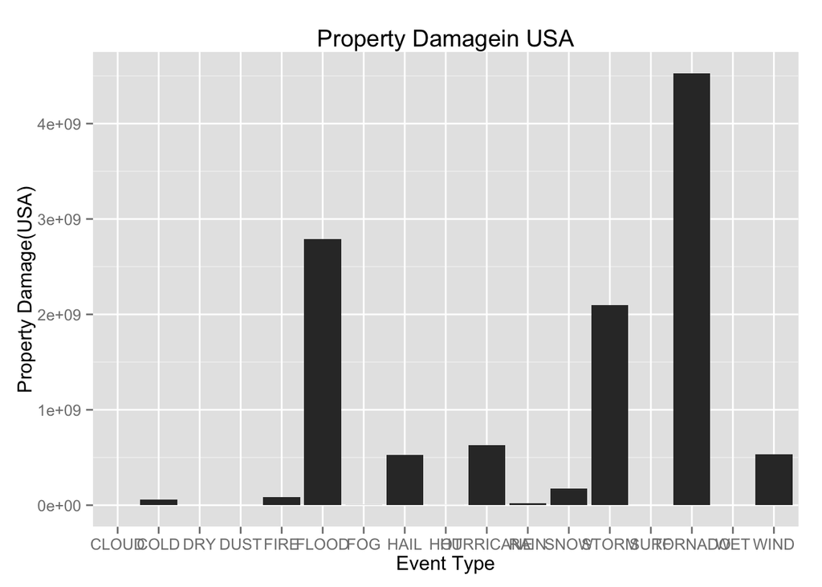

```r
new2SDProp <- aggregate(PROPDMGreal ~ EVTYPE, new2SD, sum)
new2SDCrop <- aggregate(CROPDMGreal ~ EVTYPE, new2SD, sum)

### Economic damage chart
# Property damage
ggplot(new2SDProp, aes(EVTYPE, PROPDMGreal)) + geom_bar(stat="identity") + labs(x= "Event Type", y="Property Damage(USA)", title="Property Damagein USA")
```

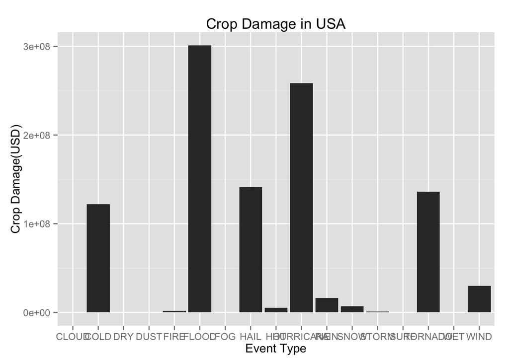

```r
# Crop damage
ggplot(new2SDCrop, aes(EVTYPE, CROPDMGreal)) + geom_bar(stat="identity") + labs(x= "Event Type", y="Crop Damage(USD)", title="Crop Damage in USA")
```

The FLOOD is the most hamful to crop damage, but the TORNADO is the most hamful to economic consequences in total.